# 9. Nutrición y salud en la adolescencia

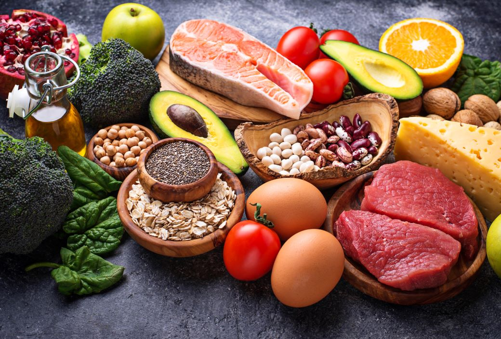

La variedad es importante para una buena nutrición - Fuente: nosequeestudiar.net

## ¿Qué es la Nutrición?

Es el proceso mediante el cual el cuerpo obtiene y utiliza los nutrientes necesarios para mantenerse sano. Durante la adolescencia, el cuerpo está en pleno crecimiento y desarrollo, lo que hace que una nutrición adecuada sea aún más importante.

## Actividad 1: Nutrientes esenciales

Los alimentos tienen nutrientes de distinto tipo. La tarea consiste en que investigues y le asignes a cada ítem de abajo el nombre del nutriente al que se refiere, El punto **a)** es un ejemplo:

1. Son esenciales para el funcionamiento de los órganos y para el crecimiento adecuado. No aportan energía ni aportan “ladrillos” para construir y reparar las células: **Se trata de las vitaminas y minerales**
2. Son la fuente más primaria y común de energía para el cuerpo. Cuando se consume en exceso el organismo lo almacena como grasa: …
3. Aportan como los “ladrillos” para la construcción y reparación de las células musculares y de otros tipos: …
4. Pueden convertirse en energía para las células pero no es la fuente primaria de energía, más bien se usa cuando se agota la fuente primaria. Nuestro cuerpo puede acumularla como si fuera una reserva. Su exceso es normalmente malo…

## La Adolescencia y las Necesidades Nutricionales

Durante la adolescencia, los jóvenes experimentan cambios hormonales y de crecimiento que aumentan sus necesidades nutricionales. Se requieren más calorías, proteínas, calcio, hierro y otros nutrientes clave. Una dieta balanceada durante esta etapa es importante para el desarrollo físico y mental.

**Recomendaciones:**

- Comer frutas y verduras a diario.
- Incluir fuentes de proteínas magras (pollo, pescado, legumbres).
- Evitar el exceso de comida rápida y alimentos ultraprocesados.
- Mantener una hidratación adecuada, preferiblemente con agua.

## Actividad 2

1. Buscar en el diccionario y escribir el significado de las siguientes palabras que aparecen en el punto anterior: hormona, caloría, magra.
2. De acuerdo a las recomendaciones del punto anterior reflexiona y con sinceridad escribe si hay algún alimento que deberías **evitar** un poco más en tu dieta y si hay algún alimento que deberías **incluir** más en tu dieta.
3. En caso de que hubiera ¿Qué obstáculos hay para comer mejor en tu caso concreto?

## Malnutrición, Desnutrición y Obesidad

Estos términos se refieren a desequilibrios nutricionales que pueden tener efectos negativos en la salud.

### Malnutrición

Es el resultado de una dieta desequilibrada, ya sea por deficiencia o exceso de nutrientes. La malnutrición puede ser tanto por falta de nutrientes como por un consumo excesivo de alimentos poco saludables.

### Desnutrición

Se refiere a una falta grave de nutrientes esenciales, como proteínas, vitaminas y minerales. Puede causar problemas graves de salud, como retraso en el crecimiento, debilidad muscular y trastornos en el sistema inmunológico.

### Obesidad

Es el exceso de grasa corporal que puede aumentar el riesgo de enfermedades como la diabetes tipo 2, hipertensión y enfermedades cardiovasculares. En la adolescencia, la obesidad se está volviendo cada vez más común debido a la mala alimentación y la falta de actividad física.

## Actividad 3

En base al punto anterior escribe el texto de abajo. Completa las palabras faltantes. Encierra estas palabras en un “circulito”.

La malnutrición es un ______ en la alimentación, que puede deberse tanto a ______ como a excesos de nutrientes. La desnutrición es una forma grave de malnutrición por falta de nutrientes ______, y puede afectar seriamente la salud. En cambio, la ______ implica un exceso de ______ corporal, aumentando el riesgo de enfermedades como diabetes y problemas cardiovasculares. En los adolescentes, la obesidad se relaciona con malos ______ alimenticios y sedentarismo.